# SwiftKey Capstone Project

Nick Oswald

11/11/2014

## Exploratory Analysis

This model will take three corpus documents (news, blogs, and tweets) and create an n-gram prediction algorithm that will predict the next word written as the user types within a text box. At the moment, this is in the exploratory phase of the project and will evaluate various n-gram models to decide what works best and how to implement the model going forward.

```r
#make sure java is installed on your version of linux (tested on linux Mint
#using ubuntu documentation)
#https://help.ubuntu.com/community/Java
#make sure Weka is installed on OS before running
#http://www.cs.waikato.ac.nz/ml/weka/downloading.html
#set JVM max heap memory parameter using 24gb of RAM before loading JVM
options(java.parameters = "-Xmx24000m")
require(knitr)
require(scales) #for formatting output into percent
```

```r
require(Rgraphviz) #for plotting in tm package
require(tm) #main text mining package in r
require(qdap) #used for sentence detection in r and requires xml and Rcurl on base linux system
require(sqldf) #to perform sql queries on r data frames
require(SnowballC) #for misc parallelization
require(doMC) #for misc parallelization
require(RWeka) #java based library in R for n-gram creation
require(openNLP) #similar to RWeka, for NLP processing
require(wordcloud) #for data visualization
require(RColorBrewer) #for color visualization
require(ggplot2) #for graphing
registerDoMC(cores = 8) #to parallelize processes as much as possible
RawDataDirectory <- "/media/noswald/BackupHardDisk/School/Data Science - Coursera/Class 10 - Capstone SwiftKey/final/en_US"
ModelDirectory <- "/media/noswald/BackupHardDisk/School/Data Science - Coursera/Class 10 - Capstone SwiftKey/model"
ProfanityLocation <- "/media/noswald/BackupHardDisk/School/Data Science - Coursera/Class 10 - Capstone SwiftKey/model/profanity.txt"
```

Load in the first 10,000 lines of three documents and perform simple summary statistics

```r
#must set directory within the same chunk as readLines function for knitR to function correctly
setwd(RawDataDirectory)
blogs <- readLines("en_US.blogs.txt", 10000)
news <- readLines("en_US.news.txt", 10000)
tweets <- readLines("en_US.twitter.txt", 10000)
```

```r
system("du -a -h | sort -hr")
system("wc -l en_US.blogs.txt")
system("wc -l en_US.news.txt")
system("wc -l en_US.twitter.txt")
```

[output not shown]

Now we combine the three vectors into one and perform sentence detection to allow or n-gram models to predict across multiple lines.

```r
sample_text <- paste(blogs, news, tweets)
sample_text <- sent_detect(sample_text, language = "en", model = NULL)
```

### Creating the Corpus and cleaning the data

Now we create the corpus and remove out information that cannot be used for text prediction such as whitespace, numbers, punctuation, etc.

```r
sample_corpus <- VCorpus(VectorSource(sample_text))
sample_corpus <- tm_map(sample_corpus, removePunctuation)
sample_corpus <- tm_map(sample_corpus, stripWhitespace)
sample_corpus <- tm_map(sample_corpus, removeNumbers)
sample_corpus <- tm_map(sample_corpus, content_transformer(tolower))
```

Remove profanity (list taken from online source)

```r
profanity <- VectorSource(readLines(ProfanityLocation))
sample_corpus <- tm_map(sample_corpus, removeWords, profanity)
```

Convert the sample corpus to a data frame to plug into RWeka Tokenizer

```r
sample_df <- data.frame(text=unlist(sapply(sample_corpus, '[',"content")),stringsAsFactors=F)
```

Create tokenizers

```r
token_delim <- " \\t\\r\\n.!?,;\"()"

onetoken <- NGramTokenizer(sample_df, Weka_control(min=1,max=1))
bitoken <- NGramTokenizer(sample_df, Weka_control(min=2,max=2, delimiters = token_delim))
tritoken <- NGramTokenizer(sample_df, Weka_control(min=3,max=3, delimiters = token_delim))
quatrtoken <- NGramTokenizer(sample_df, Weka_control(min=4,max=4, delimiters = token_delim))
```

Now we setup the comparison data from our tokenizers to understand the data better

```r
one_word <- data.frame(table(onetoken))
two_word <- data.frame(table(bitoken))
three_word <- data.frame(table(tritoken))
four_word <- data.frame(table(quatrtoken))

sort_one <- one_word[order(one_word$Freq,decreasing=TRUE),]
colnames(sort_one) <- c("Word", "Freq")
sort_two <- two_word[order(two_word$Freq,decreasing=TRUE),]
colnames(sort_two) <- c("Word", "Freq")
sort_three <- three_word[order(three_word$Freq,decreasing=TRUE),]
colnames(sort_three) <- c("Word", "Freq")
sort_four <- four_word[order(four_word$Freq,decreasing=TRUE),]
colnames(sort_four) <- c("Word", "Freq")
```

### Wordclouds for Visualization

We compare the distributions of tokenized words in our two, three, and four gram tokenizers. The more common the word or phrase, the bigger it is within each word cloud.

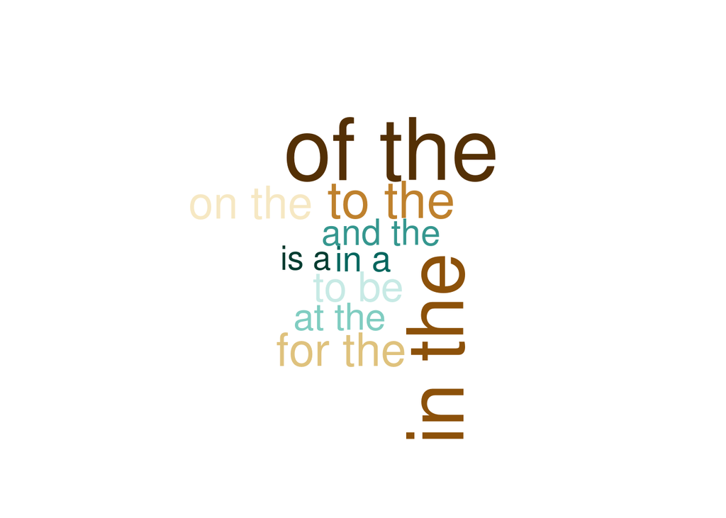

```r
wordcloud(words = sort_two[1:10,1], freq = sort_two[1:10,2], scale = c(5,1), colors = brewer.pal(10,"BrBG"),ordered.colors = TRUE)
```

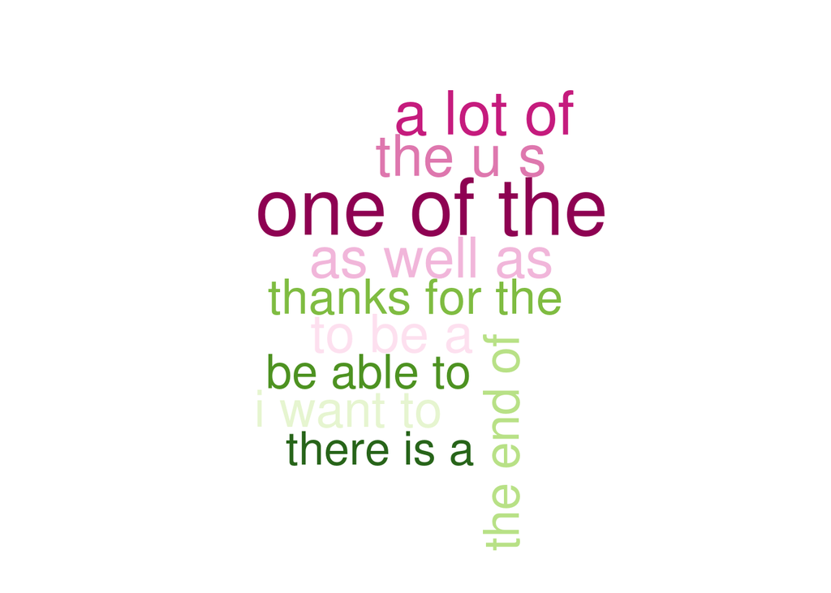

```r
wordcloud(words = sort_three[1:10,1], freq = sort_three[1:10,2], scale = c(4,1), colors = brewer.pal(10,"PiYG"), ordered.colors = TRUE)
```

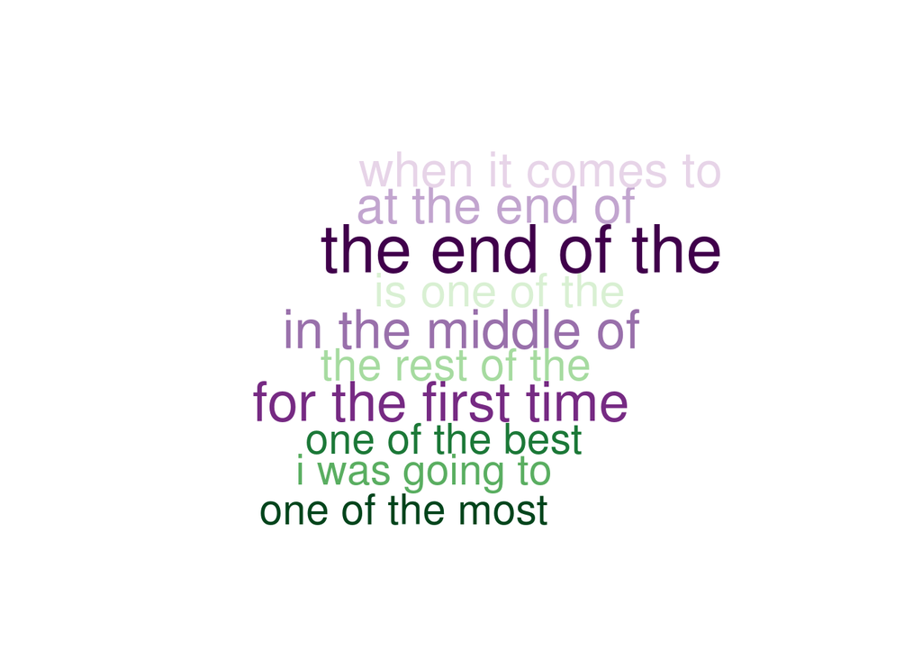

```r
wordcloud(words = sort_four[1:10,1], freq = sort_four[1:10,2], scale = c(3,1), colors = brewer.pal(10, "PRGn"), ordered.colors = TRUE)
```

### Analyzing Word Frequencies

Assuming all words used in the English language come from our sample of corpora (a very big assumption!), we can see in the following calculation how many words it would take to reach 50% and 90% coverage in our one word model.

```r
sort_one_freq <- cbind(sort_one,sort_one$Freq/sum(sort_one$Freq))
colnames(sort_one_freq) <- c("Word", "Freq", "Pct_Freq")
running_freq = 0
words_counted = 0
while(running_freq<0.50){
  running_freq <- running_freq + sort_one_freq[(words_counted+1),3]
  words_counted <- words_counted + 1
  }
```

139 words are needed to account for 50% of the entire frequency corpora. This is the same as 0.658% of the rows in our one-word sample corpus.

```r
sort_one_freq <- cbind(sort_one,sort_one$Freq/sum(sort_one$Freq))
colnames(sort_one_freq) <- c("Word", "Freq", "Pct_Freq")
running_freq = 0
words_counted = 0
while(running_freq<0.90){
  running_freq <- running_freq + sort_one_freq[(words_counted+1),3]
  words_counted <- words_counted + 1
  }
```

6414 words are needed to account for 90% of the entire frequency corpora. This is the same as 30.4% of the rows in our one-word sample corpus.